# Predicting Major-Donor Threshold Crossings Using Solicitation Features

## Objective and Data

The objective is to compare Logistic Regression, Elastic Net, Random Forest, and XGBoost for predicting which constituents will cross the major-donor threshold in the following fiscal year. A new major donor is defined here as someone who gives less than **$1,200** in the feature year and at least **$1,200** in the following fiscal year. Annual giving includes direct payments and soft credits. The analysis includes only constituent-years eligible to cross this threshold.

Each algorithm is evaluated twice: once using the available non-solicitation predictors and once with solicitation-response predictors added. The models are compared using chronological validation, with average precision as the primary performance metric because major-donor conversions are rare. FY2025 feature rows and FY2026 outcomes are reserved for the group’s final combined-model evaluation.

The solicitation-response measures require cautious interpretation. A response is identified through a same-constituent, same-marketing-code payment within the fiscal year; this is a proxy for response, not evidence that the solicitation caused the gift. Campaign dates identify fiscal years rather than verified contact dates.

## Setup

```r
library(readr)
library(caret)
library(dplyr)
library(tidyr)
library(readr)
library(tibble)
library(ggplot2)
library(pROC)
library(glmnet)
library(randomForest)
library(xgboost)
library(gt)

options(tibble.print_max = Inf, tibble.width = Inf)
RANDOM_SEED <- 42
```

```r
# Load the analytic dataset
analytic <- read_csv(
  "Data_Files/constituent_fiscal_year_analytic.csv",
  show_col_types = FALSE
)

# Keep eligible constituents from development years
dev <- analytic %>%
  filter(
    fiscal_year %in% 2021:2024,
    annual_giving < 1200,
    !is.na(major_donor_next_fy)
  )

# Remove unfiltered data
rm(analytic)
```

## Temporal Validation

Three expanding-window folds test whether models trained on earlier years can predict outcomes in a later year. The first trains on FY2021 features and validates on FY2022 features (FY2023 outcomes); the second trains on FY2021 and FY2022 features and validates on FY2023 features (FY2024 outcomes); the third trains on FY2021 through FY2023 features and validates on FY2024 features (FY2025 outcomes).

Predictions are assumed to occur after the validation feature year has ended, when that year’s giving and solicitation information is available. The outcome column already refers to giving in the following fiscal year, so no additional shift is needed. All three folds are used to compare models; the FY2025-feature/FY2026-outcome holdout is not used here.

```r
folds <- tibble(
  fold = 1:3,
  training_years = c("2021", "2021-2022", "2021-2023"),
  feature_year = 2022:2024,
  outcome_year = 2023:2025
)

gt(folds)
```

| fold | training_years | feature_year | outcome_year |
| --- | --- | --- | --- |
| 1 | 2021 | 2022 | 2023 |
| 2 | 2021-2022 | 2023 | 2024 |
| 3 | 2021-2023 | 2024 | 2025 |

## Predictor Sets

To evaluate the incremental predictive value of solicitation-response information, each model is fitted with two predictor sets on the same eligible constituent-years. The baseline includes 16 non-solicitation predictors, while the expanded set adds 23 solicitation-related predictors covering solicitation counts, response measures, campaign activity, and historical rates. Numeric predictors are selected after excluding identifiers, the target, future-year fields, and specified snapshot and cultivation fields. The comparison therefore tests whether adding solicitation-related variables improves predictions beyond the baseline predictors.

```r
# Remove fields that could leak future information or identify a constituent.
excluded <- grepl(
  "^next_fy_|_snapshot$|^cultivation_",
  names(dev)
) |
  names(dev) %in% c(
    "constituent_id",
    "fiscal_year",
    "data_split",
    "major_donor_next_fy"
  )

# Keep numeric predictors and identify every solicitation-related feature.
candidates <- names(dev)[!excluded & vapply(dev, is.numeric, logical(1))]
solicitation <- candidates[grepl(
  "^(solicitations|responses|campaign_|unique_campaigns_solicited|prior_fy_solicitations|prior_fy_campaign_responses|trailing_3_fy_solicitations|trailing_3_fy_campaign_responses|trailing_3_fy_response_rate)",
  candidates
)]

# The two sets differ only in whether solicitation features are included.
feature_sets <- list(
  without_solicitation = setdiff(candidates, solicitation),
  with_solicitation = candidates
)

gt(tibble(feature_set = names(feature_sets), predictors = lengths(feature_sets)))
```

| feature_set | predictors |
| --- | --- |
| without_solicitation | 16 |
| with_solicitation | 39 |

## Training Preparation

Major-donor conversions are uncommon, so each training fold retains every positive case and randomly samples up to 50 negative cases per positive case to reduce computation. Validation uses every eligible observation, preserving the actual outcome frequency. Missing predictor values are replaced with medians calculated from the sampled training data, and predictors that are constant in that sample are removed. These preprocessing decisions are then applied to the validation data.

Because negative sampling changes the proportion of positive cases used for fitting, predicted probabilities are adjusted using the difference between sampled and original training prevalence. This correction preserves the ranking of predictions but does not guarantee well-calibrated probabilities, particularly for ensemble models.

```r
prepare_features <- function(columns, train_data, valid_data, sampled_rows) {

  # Select the same predictors for training and validation
  x_train <- train_data[sampled_rows, columns, drop = FALSE]
  x_valid <- valid_data[, columns, drop = FALSE]

  # Replace missing values using training medians
  for (column in columns) {
    median_value <- median(x_train[[column]], na.rm = TRUE)

    if (!is.finite(median_value)) {
      median_value <- 0
    }

    x_train[[column]][is.na(x_train[[column]])] <- median_value
    x_valid[[column]][is.na(x_valid[[column]])] <- median_value
  }

  # Remove predictors that are constant in the training sample
  varying <- vapply(
    x_train,
    function(x) length(unique(x)) > 1,
    logical(1)
  )

  x_train <- x_train[, varying, drop = FALSE]
  x_valid <- x_valid[, varying, drop = FALSE]

  list(train = x_train, valid = x_valid)
}

# Adjust predicted probabilities for the altered training class proportions
correct_probability <- function(probability, population_prior, sample_prior) {
  probability <- pmin(pmax(as.numeric(probability), 1e-8), 1 - 1e-8)

  plogis(
    qlogis(probability) +
      qlogis(population_prior) -
      qlogis(sample_prior)
  )
}
```

## Model Training

Four classification algorithms are compared: Logistic Regression as a conventional benchmark, Elastic Net as a regularized logistic regression model, Random Forest as a bagged tree ensemble, and XGBoost as a gradient-boosted tree ensemble. Each algorithm is fitted separately for both predictor sets across three chronological validation folds, producing 24 model fits in total.

Hyperparameters are fixed rather than optimized through an additional tuning procedure. Elastic Net uses centered and scaled predictors, while the other models use the imputed predictors directly. Each fitted model generates predicted probabilities for the full validation population, which are adjusted for the altered training class proportions before evaluation.

```r
# Fixed model settings for benchmark comparisons
control <- trainControl(
  method = "none",
  classProbs = TRUE,
  allowParallel = FALSE
)

fit_models <- function(x_train, x_valid, y_train) {

  # Remove linearly dependent predictors for ordinary logistic regression
  design <- cbind(Intercept = 1, as.matrix(x_train))
  independent <- qr(design)$pivot[seq_len(qr(design)$rank)]
  glm_columns <- setdiff(colnames(design)[independent], "Intercept")

  # Logistic regression
  set.seed(RANDOM_SEED)

  logistic <- train(
    x = x_train[, glm_columns, drop = FALSE],
    y = y_train,
    method = "glm",
    family = binomial(),
    trControl = control
  )

  # Elastic net logistic regression
  set.seed(RANDOM_SEED)

  elastic <- train(
    x = x_train,
    y = y_train,
    method = "glmnet",
    family = "binomial",
    preProcess = c("center", "scale"),
    tuneGrid = data.frame(
      alpha = 0.5,
      lambda = 0.01
    ),
    trControl = control
  )

  # Random forest
  set.seed(RANDOM_SEED)

  forest <- train(
    x = x_train,
    y = y_train,
    method = "rf",
    ntree = 200,
    tuneGrid = data.frame(
      mtry = max(1, floor(sqrt(ncol(x_train))))
    ),
    trControl = control
  )

  # XGBoost
  set.seed(RANDOM_SEED)

  boost <- xgboost::xgb.train(
    data = xgboost::xgb.DMatrix(
      as.matrix(x_train),
      label = as.integer(y_train == "yes")
    ),
    params = list(
      objective = "binary:logistic",
      max_depth = 3,
      eta = 0.05,
      colsample_bytree = 0.8,
      subsample = 0.8,
      nthread = 1
    ),
    nrounds = 100,
    verbose = 0
  )

  # Predict probabilities on the full validation population
  list(
    `Logistic Regression` = predict(
      logistic,
      x_valid[, glm_columns, drop = FALSE],
      type = "prob"
    )$yes,

    `Elastic Net` = predict(
      elastic,
      x_valid,
      type = "prob"
    )$yes,

    `Random Forest` = predict(
      forest,
      x_valid,
      type = "prob"
    )$yes,

    XGBoost = predict(
      boost,
      xgboost::xgb.DMatrix(as.matrix(x_valid))
    )
  )
}
```

```r
predictions <- bind_rows(lapply(seq_len(nrow(folds)), function(fold) {

  # Select training and validation years
  train_data <- dev %>%
    filter(fiscal_year < folds$feature_year[fold])

  valid_data <- dev %>%
    filter(fiscal_year == folds$feature_year[fold])

  # Identify positive and negative training observations
  y_full <- train_data$major_donor_next_fy

  positive <- which(y_full == 1)
  negative <- which(y_full == 0)

  # Keep every positive and sample up to 50 negatives per positive
  set.seed(RANDOM_SEED + fold)

  sampled_rows <- sort(c(
    positive,
    sample(
      negative,
      min(length(negative), 50L * length(positive))
    )
  ))

  # Create training outcome
  y_train <- factor(
    ifelse(y_full[sampled_rows] == 1, "yes", "no"),
    levels = c("yes", "no")
  )

  # Verify both outcome classes are represented
  stopifnot(all(table(y_train) > 0))

  # Calculate class proportions for probability correction
  population_prior <- mean(y_full == 1)
  sample_prior <- mean(y_full[sampled_rows] == 1)

  # Compare models with and without solicitation features
  bind_rows(lapply(names(feature_sets), function(feature_set) {

    features <- prepare_features(
      feature_sets[[feature_set]],
      train_data,
      valid_data,
      sampled_rows
    )

    # Fit four models and predict validation outcomes
    scores <- fit_models(
      features$train,
      features$valid,
      y_train
    )

    # Store predictions for each model
    bind_rows(lapply(names(scores), function(model) {

      corrected <- correct_probability(
        scores[[model]],
        population_prior,
        sample_prior
      )

      tibble(
        fold = fold,
        feature_year = folds$feature_year[fold],
        outcome_year = folds$outcome_year[fold],
        model = model,
        feature_set = feature_set,
        outcome = valid_data$major_donor_next_fy,
        probability = corrected
      )
    }))
  }))
}))
```

## Model Evaluation and Comparison

Each model’s predictions are evaluated against observed next-year major-donor conversions using average precision, ROC AUC, and Brier score. **Average precision** is the primary selection metric because it measures how effectively a model ranks rare positive cases. ROC AUC measures discrimination between positive and negative cases, while the Brier score measures squared probability error (lower is better). The number and percentage of eventual major donors captured within the top 5%, 10%, and 20% of ranked constituents are also calculated to assess potential usefulness for donor prioritization.

```r
score_model <- function(data) {

  # Rank constituents by predicted probability
  ranked <- data %>% arrange(desc(probability))

  outcomes <- ranked$outcome
  n <- nrow(ranked)
  positives <- sum(outcomes)

  # Calculate average precision, accounting for tied scores
  score_groups <- ranked %>%
    group_by(probability) %>%
    summarise(
      n_group = n(),
      positives_group = sum(outcome),
      .groups = "drop"
    ) %>%
    arrange(desc(probability)) %>%
    mutate(
      cumulative_n = cumsum(n_group),
      cumulative_positives = cumsum(positives_group),
      precision = cumulative_positives / cumulative_n
    )

  average_precision <- if (positives > 0) {
    sum(
      score_groups$precision * score_groups$positives_group
    ) / positives
  } else {
    NA_real_
  }

  # Define top-ranked groups
  top_5 <- ceiling(0.05 * n)
  top_10 <- ceiling(0.10 * n)
  top_20 <- ceiling(0.20 * n)

  # Count major donors captured in each group
  captured_5 <- sum(head(outcomes, top_5))
  captured_10 <- sum(head(outcomes, top_10))
  captured_20 <- sum(head(outcomes, top_20))

  tibble(
    average_precision = average_precision,

    roc_auc = if (length(unique(outcomes)) == 2) {
      as.numeric(pROC::auc(pROC::roc(
        outcomes,
        ranked$probability,
        levels = c(0, 1),
        direction = "<",
        quiet = TRUE
      )))
    } else {
      NA_real_
    },

    brier = mean((ranked$probability - outcomes)^2),

    captured_top_5pct = captured_5,
    captured_top_10pct = captured_10,
    captured_top_20pct = captured_20,

    capture_rate_top_5pct = if (positives > 0) {
      captured_5 / positives
    } else NA_real_,

    capture_rate_top_10pct = if (positives > 0) {
      captured_10 / positives
    } else NA_real_,

    capture_rate_top_20pct = if (positives > 0) {
      captured_20 / positives
    } else NA_real_
  )
}

# Evaluate each model within each validation fold
comparison <- predictions %>%
  group_by(fold, feature_year, outcome_year, model, feature_set) %>%
  group_modify(~ score_model(.x)) %>%
  ungroup()
```

Performance is compared across eight model configurations: four algorithms, each evaluated with and without solicitation-response predictors. Each metric is averaged equally across the three chronological validation folds, and configurations are ranked by mean average precision. Because validation years contain different numbers of conversions, these unweighted fold averages describe typical yearly performance rather than pooled performance across all observations.

```r
# Summarize performance across validation folds
model_summary <- comparison %>%
  group_by(model, feature_set) %>%
  summarise(
    mean_precision = mean(average_precision, na.rm = TRUE),
    mean_roc_auc = mean(roc_auc, na.rm = TRUE),
    mean_brier = mean(brier, na.rm = TRUE),
    .groups = "drop"
  ) %>%
  arrange(desc(mean_precision))

# Display model comparison
model_summary %>%
  gt() %>%
  fmt_number(
    columns = c(mean_precision, mean_roc_auc),
    decimals = 3
  ) %>%
  fmt_number(
    columns = mean_brier,
    decimals = 6
  )
```

| model | feature_set | mean_precision | mean_roc_auc | mean_brier |
| --- | --- | --- | --- | --- |
| XGBoost | with_solicitation | 0.192 | 0.941 | 0.000233 |
| Random Forest | with_solicitation | 0.185 | 0.927 | 0.000234 |
| XGBoost | without_solicitation | 0.184 | 0.928 | 0.000234 |
| Elastic Net | with_solicitation | 0.177 | 0.927 | 0.000252 |
| Elastic Net | without_solicitation | 0.176 | 0.927 | 0.000252 |
| Logistic Regression | without_solicitation | 0.158 | 0.926 | 0.000288 |
| Random Forest | without_solicitation | 0.156 | 0.921 | 0.000256 |
| Logistic Regression | with_solicitation | 0.148 | 0.904 | 0.000300 |

XGBoost with solicitation-response predictors achieved the highest mean average precision (0.192), followed by Random Forest with solicitation predictors (0.185) and XGBoost without solicitation predictors (0.184). Adding solicitation features improved XGBoost’s mean average precision from 0.184 to 0.192 and Random Forest’s from 0.156 to 0.185. Elastic Net improved only slightly, from 0.176 to 0.177, while Logistic Regression declined from 0.158 to 0.148.

XGBoost with solicitation features also achieved the highest mean ROC AUC (0.941) and lowest mean Brier score (0.000233). These results suggest that solicitation-response information provides incremental predictive value for some algorithms, particularly tree-based ensembles. However, the improvements are modest for XGBoost, and performance should be interpreted cautiously because the evaluation includes only three chronological validation folds.

### Highlight: Best-Performing Models

This table isolates the algorithm and feature configuration with the best mean score for each evaluation metric across the three folds. Higher average precision and ROC AUC are preferred, while lower Brier score is preferred.

```r
best_models <- model_summary %>%
  select(
    model,
    feature_set,
    mean_precision,
    mean_roc_auc,
    mean_brier
  ) %>%
  pivot_longer(
    cols = starts_with("mean_"),
    names_to = "metric",
    values_to = "value"
  ) %>%
  group_by(metric) %>%
  slice_max(
    order_by = if_else(metric == "mean_brier", -value, value),
    n = 1,
    with_ties = TRUE
  ) %>%
  ungroup() %>%
  arrange(metric)

best_models %>%
  gt() %>%
  fmt_number(columns = value, decimals = 4)
```

| model | feature_set | metric | value |
| --- | --- | --- | --- |
| XGBoost | with_solicitation | mean_brier | 0.0002 |
| XGBoost | with_solicitation | mean_precision | 0.1916 |
| XGBoost | with_solicitation | mean_roc_auc | 0.9406 |

XGBoost with solicitation-response predictors achieved the best mean performance across all three evaluation metrics: average precision (0.1916), ROC AUC (0.9406), and Brier score (approximately 0.000233). Because average precision is the primary selection metric, this configuration is selected as the leading development-stage model. However, its advantage over competing configurations is relatively small, and these results do not establish that it will consistently outperform alternatives on future data.

## Solicitation-Response Feature Importance

Because XGBoost with solicitation-response predictors achieved the highest mean average precision during temporal validation, an additional XGBoost model is fitted using all FY2021–FY2024 development data. The model uses the same preprocessing, negative sampling strategy, and hyperparameters as the validation models.

Feature importance is measured using **gain**, which represents the relative improvement in XGBoost’s training objective associated with splits using each predictor. The first plot displays feature importance across all predictors, while the second focuses specifically on solicitation-related predictors. Both plots use gain values from the same fitted model, allowing their relative contributions to be compared directly.

```r
# Identify positive and negative development observations
y_full <- dev$major_donor_next_fy

positive <- which(y_full == 1)
negative <- which(y_full == 0)

# Apply the same negative sampling strategy
set.seed(RANDOM_SEED + 4)

sampled_rows <- sort(c(
  positive,
  sample(
    negative,
    min(length(negative), 50L * length(positive))
  )
))

# Prepare predictors using the full development period
features <- prepare_features(
  feature_sets$with_solicitation,
  dev,
  dev,
  sampled_rows
)

# Fit XGBoost using the same hyperparameters
set.seed(RANDOM_SEED)

boost <- xgboost::xgb.train(
  data = xgboost::xgb.DMatrix(
    as.matrix(features$train),
    label = as.integer(y_full[sampled_rows])
  ),
  params = list(
    objective = "binary:logistic",
    max_depth = 3,
    eta = 0.05,
    colsample_bytree = 0.8,
    subsample = 0.8,
    nthread = 1
  ),
  nrounds = 100,
  verbose = 0
)
```

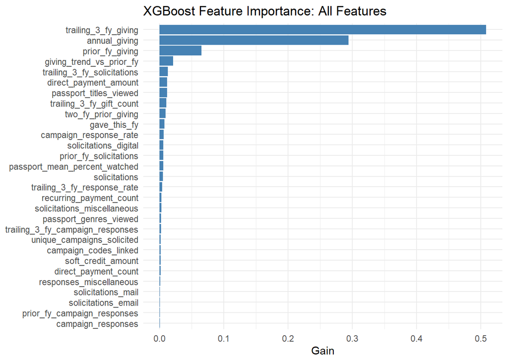

```r
# Calculate feature importance for all predictors
importance <- xgboost::xgb.importance(
  model = boost
)

# Plot importance for all features
ggplot(
  importance,
  aes(x = reorder(Feature, Gain), y = Gain)
) +
  geom_col(fill = "steelblue") +
  coord_flip() +
  labs(
    title = "XGBoost Feature Importance: All Features",
    x = NULL,
    y = "Gain"
  ) +
  theme_minimal()
```

The all-features plot shows that historical giving is substantially more influential than solicitation activity. **Trailing three-year giving**, **annual giving**, and **prior-year giving** are the three most important predictors, with trailing three-year giving contributing the greatest gain. This suggests that historical giving behavior is the strongest source of predictive information in the fitted model.

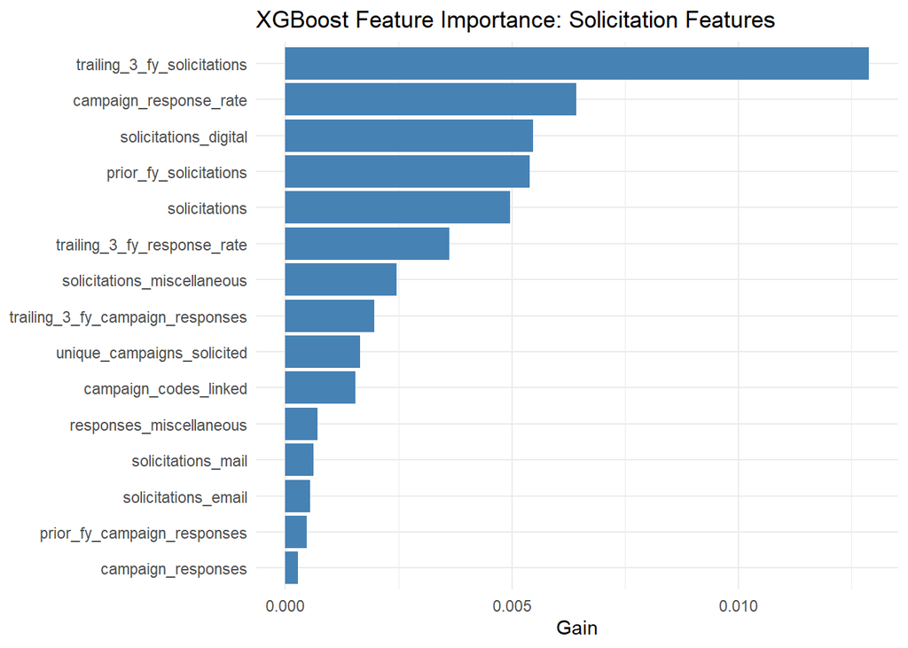

```r
# Identify solicitation-related features
solicitation_importance <- importance %>%
  filter(Feature %in% solicitation) %>%
  arrange(desc(Gain))

# Plot importance for solicitation features
ggplot(
  solicitation_importance,
  aes(x = reorder(Feature, Gain), y = Gain)
) +
  geom_col(fill = "steelblue") +
  coord_flip() +
  labs(
    title = "XGBoost Feature Importance: Solicitation Features",
    x = NULL,
    y = "Gain"
  ) +
  theme_minimal()
```

Among solicitation-related predictors, **trailing three-year solicitations** has the highest importance, followed by **campaign response rate**, **digital solicitations**, **prior-year solicitations**, and **current-year solicitations**. Trailing three-year solicitations also ranks fifth among all predictors, indicating that historical solicitation activity provides information used by the model beyond giving history.

However, the importance of individual solicitation predictors remains relatively small compared with the dominant giving-history variables. Correlated predictors may share importance, and gain does not establish the direction or causal effect of a predictor’s relationship with future giving. The incremental predictive value of solicitation-response information is therefore better assessed through the held-out validation comparisons than through feature importance alone.

## Conclusion

Across three chronological validation folds, XGBoost with solicitation-response predictors achieved the highest mean average precision (0.192), ROC AUC (0.941), and lowest mean Brier score (0.000233) among the eight model configurations. Adding solicitation features increased XGBoost’s mean average precision from 0.184 to 0.192, suggesting a modest improvement in identifying constituents likely to cross the major-donor threshold.

The benefit of solicitation-response predictors varied by algorithm. Random Forest also improved with these features, while Elastic Net showed little change and Logistic Regression performed worse. This suggests that the additional predictive information may be better captured by nonlinear tree-based models.

Feature importance indicates that historical giving behavior is the dominant source of predictive information. Trailing three-year giving, annual giving, and prior-year giving were the most influential predictors. Among solicitation-related features, trailing three-year solicitations contributed the most, followed by campaign response rate and digital solicitation activity.

Overall, solicitation-response features appear to provide useful supplementary predictive information, although their contribution is relatively modest compared with giving history. These associations should not be interpreted as evidence that solicitation activity causes increased giving, particularly because solicitation responses are identified using payment-based proxies.

**XGBoost with solicitation-response predictors is recommended as the leading development-stage model.** However, this recommendation is based on three temporal validation folds and fixed hyperparameters rather than a comprehensive tuning procedure. The FY2025-feature/FY2026-outcome holdout remains reserved for evaluating the group’s combined model using all available feature groups.